# Milestone Report #01

Rafael Gurgel

14/02/2018

## Introduction

This report is part of the last module of Data Science specialization from Coursera. You can check the .rmd source on my [github account](https://github.com/rafagurgel/keyboard_predictions/tree/master/ExploratoryData) The project (final) goal is to build text prediction models from a dataset based on Twitter, blogs and news. This preliminar report explores the data available [here](https://d396qusza40orc.cloudfront.net/dsscapstone/dataset/Coursera-SwiftKey.zip). This file contains data from 4 different languages (divided in 4 different folders). We’re going to analyse only the English dataset.

## Exploratory analysis

The exploratory analysis is made using `tidytext` and `quanteda` because their easy of use and capacity to tidy the data. The first step is loading the data.

We summarize the lines (text sample) from the dataset loaded, by the total of sentences, words(tokens) and unique words (types). The expected size of this variables by sample (line) are also calculated using the mean.

| Source | Lines | Sentences (total) | Sentences (mean) | Words (total) | Words (mean) | Unique words by line (total) | Unique words by line (mean) |
| --- | --- | --- | --- | --- | --- | --- | --- |
| blogs | 850042 | 2312359 | 2.720288 | 42612645 | 50.13005 | 31136606 | 36.62949 |
| news | 74660 | 149924 | 2.008090 | 3053425 | 40.89774 | 2448158 | 32.79076 |
| twitter | 2278555 | 3679275 | 1.614740 | 36355314 | 15.95543 | 32351223 | 14.19813 |

Using histograms we can also check the distribution of the sentences, tokens and types in each sample.

Sentences in a sample

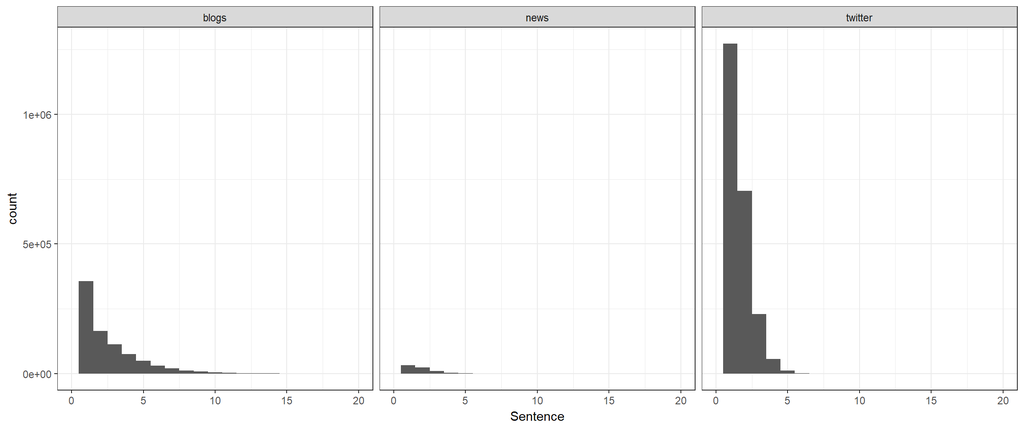

Tokens in a sample

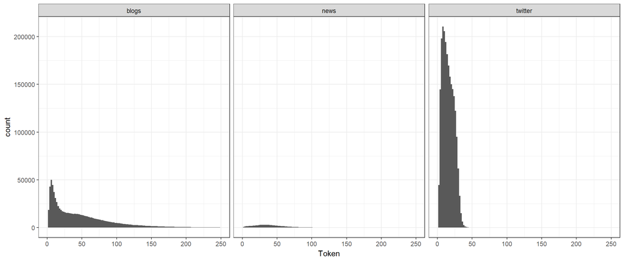

Unique words in a sample

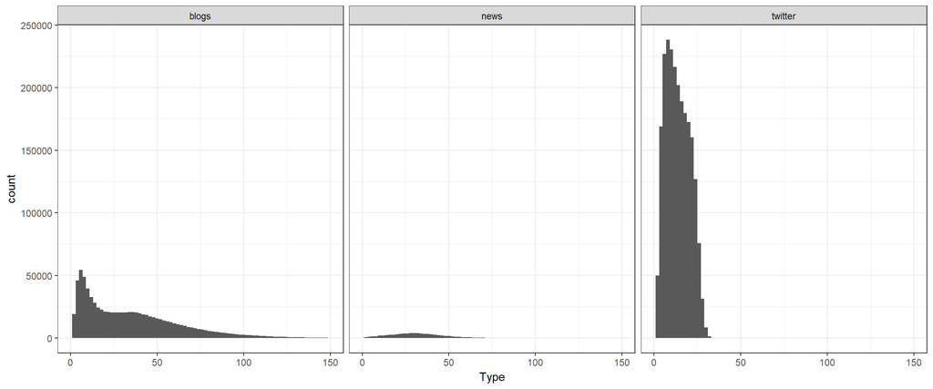

### Words Frequency

| Word | Total | Blogs | News | Twitter |
| --- | --- | --- | --- | --- |
| the | 2947391 | 1859310 | 151690 | 936391 |
| to | 1926469 | 1069070 | 69752 | 787647 |
| and | 1600752 | 1094039 | 68590 | 438123 |
| a | 1573296 | 898820 | 67292 | 607184 |
| i | 1496444 | 773629 | 11990 | 710825 |
| of | 1295092 | 876412 | 59304 | 359376 |
| in | 1029561 | 598047 | 51887 | 379627 |
| you | 850581 | 298527 | 7461 | 544593 |
| is | 812280 | 432547 | 21968 | 357765 |
| for | 776000 | 363728 | 27164 | 385108 |

#### Filters

##### Profanity filter

In order to provide decent suggestions, a profanity filter was developed trying to remove some bad words. The 10 most frequent indecent words found was

| Word | Total | Blogs | News | Twitter |
| --- | --- | --- | --- | --- |
| shit | 19447 | 2316 | 0 | 17131 |
| ass | 13950 | 1790 | 7 | 12153 |
| fuck | 13233 | 1439 | 0 | 11794 |
| damn | 12996 | 1903 | 17 | 11076 |
| fucking | 8804 | 1642 | 0 | 7162 |
| bitch | 8664 | 654 | 2 | 8008 |
| sucks | 5033 | 597 | 7 | 4429 |
| nigga | 4071 | 14 | 0 | 4057 |
| suck | 3926 | 663 | 13 | 3250 |
| dick | 3208 | 687 | 52 | 2469 |

The filter is quite inflexible with some words variations. I selected the news texts where there’s one bad word (or part of it) identified.

| News |
| --- |
| I liked theCareerBuilder.comad with the harried office worker and the chimpanzees. And I’m a sucker for the e-Trade babies, although this one yesterday wasn’t as edgy and fun as the first two incarnat… |
| One recent year we decided on Mediterranean feasting (a limoncello sparkler set the mood) while another year we sought inspiration from China, with a suckling pig as the piece de resistance. Yet anoth… |
| Alternative libations: Vodka well cocktails |
| Once while attempting to change the pilot light in his water heater, he visited a hardware store and was reassured that “any damn fool could do the job,” Karen recalled. |
| There is one caution flag for Hancock. |
| Jarrod Parker, one of the A’s most high-profile offseason prospect acquisitions, already has hopped into the rotation, and Brad Peacock, another starter from a big winter deal, could be next in line a… |
| Hitchcock said that Arnott, who has missed the last two games, had a good practice Sunday, but he is not a guarantee to Wednesday. With McDonald and Backes very doubtful, the team may need to call up … |
| “I was a little bit like, ‘Damn, we need to get going,’” sophomore Patrik Auda said. “Then we hit two good 3s and started to play good defense. That’s what it was.” |
| Grant Heppes, a 22-year-old passenger from New York City, said a man in a JetBlue uniform walked from the cockpit to the back of the plane, but he started to become disruptive when he was barred from … |
| Unlike many in the opposition movement who now view Shiites and Alawites as heretics out to kill them, Abdulaziz doesn’t believe the rhetoric. He understands that the Shiites, like the Sunnis, are afr… |

There are obviously some mismatches but I prefer to be more conservative and miss a few predictions (that’s looks so specific) than being more liberal and maybe suggesting something nasty. Only the profane words will be removed and not the full text (something similar will be done in the future when we consider de n-grams, removing only the n-grams containing one bad word).

##### Foreign words filtering

The foreign words filter will work in two levels. The first one was applying after loading the data, getting only english-identified phrases, using the packages `cld2` and `cld3`. In the word levels we search for non-ascii characters.

##### Non letters/numbers words

Words not containing any letters will be discarted.

In this part 26999 different “words” were removed.

##### Websites

Finally we’ll remove websites

In this part 5857 different websites were removed.

### Influence

To cover 50% and 90% of the words we’ll respectively need 123 and 6581 words. This is due to high frequency words like “the”, “to”, “and”. In this case the new more frequent words are the following

| Word | Total | Blogs | News | Twitter |
| --- | --- | --- | --- | --- |
| time | 171630 | 90850 | 4471 | 76309 |
| love | 148459 | 44941 | 796 | 102722 |
| day | 146155 | 52296 | 2477 | 91382 |
| people | 115251 | 59556 | 3673 | 52022 |
| rt | 89497 | 97 | 3 | 89397 |
| life | 76164 | 41207 | 1219 | 33738 |
| lol | 71657 | 2966 | 3 | 68688 |
| happy | 62622 | 13430 | 382 | 48810 |
| night | 61443 | 19120 | 1316 | 41007 |
| week | 57066 | 26255 | 1778 | 29033 |

#### Words Pairs

In order to predict words we group the words in pairs (2-grams) to define a word probability given another one. This analysis may be done also in a bigger group of words for example triples (3-grams), extending to n groups (n-grams).

| Word | Total | Blogs | News | Twitter |
| --- | --- | --- | --- | --- |
| of the | 258233 | 187213 | 14102 | 56918 |
| in the | 245069 | 153317 | 13522 | 78230 |
| for the | 137378 | 58087 | 5386 | 73905 |
| to the | 135753 | 85974 | 6409 | 43370 |
| on the | 129384 | 75410 | 5555 | 48419 |
| to be | 119060 | 68393 | 3576 | 47091 |
| at the | 88953 | 47317 | 4496 | 37140 |
| i have | 80045 | 48089 | 503 | 31453 |
| and the | 77745 | 58653 | 4033 | 15059 |
| i was | 75877 | 49569 | 845 | 25463 |

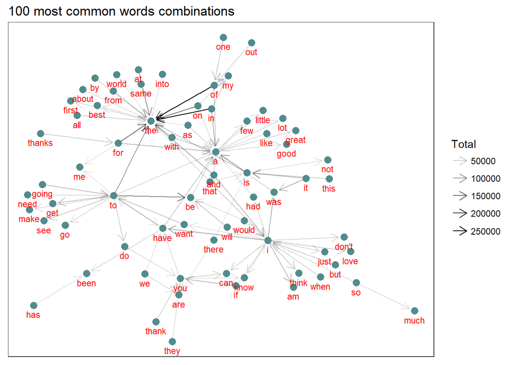

##### Removing stopwords

Removing 2-grams constructed by 2 stopwords we get

| Word | Total | Blogs | News | Twitter |
| --- | --- | --- | --- | --- |
| i love | 46677 | 12862 | 136 | 33679 |
| a lot | 32825 | 19477 | 1257 | 12091 |
| the world | 26285 | 14848 | 611 | 10826 |
| time to | 21386 | 10066 | 395 | 10925 |
| lot of | 20356 | 12841 | 905 | 6610 |
| the time | 19078 | 12809 | 599 | 5670 |
| a bit | 18265 | 14218 | 257 | 3790 |
| the day | 18062 | 8430 | 358 | 9274 |
| i hope | 17840 | 6613 | 103 | 11124 |
| i feel | 16084 | 6384 | 160 | 9540 |

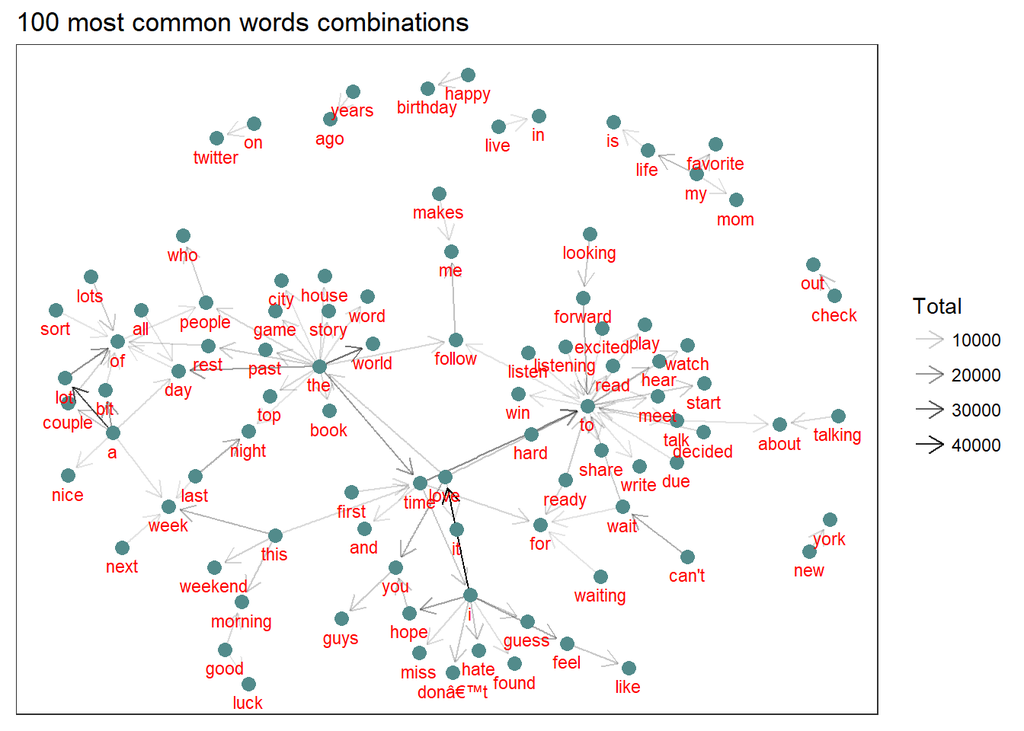

### Predictor’s criteria

Based on the probability of a word given a n-gram we’re going to build the predictor. There are some things to study like how long does the n-gram should be, and also improve the filter’s capacibility, e.g. for people names and for non-english words.